# Kutbay HW 4

Sara Kutbay

April 10, 2017

# Problem:

With the summer season approaching, the owner of the bookstore Flourish and Blotts wants to ensure that his display cases are filled with books that are both popular and related. While there is data on over 90,000 transactions, no analysis has been done to decipher which books should be paired together in displays to increase purchases.

# Objective:

Find the most popular books and any sets of books that are frequently purchased together in order to provide the book store owner with accurate information on how to arrange his display cases. Additionally, we must honor any requests that the store owner has made regarding what he would or would not like to display.

# Assumptions:

When considering creating a display that appeals to book club members, I would make the assumption that these members prefer books that are uplifting, heart-warming, and contain subject matter that can be openly discussed and related to their lives. Therefore, any books that are obviously vulgur or in the genres of horror or thrillers should be excluded from these displays. We are looking for related or popular books that fall into the category described. Additionally, we do not want to insult the book store owners intelligence by suggesting books in a series, which he knows should be displayed together, and he has requested that we do not include Wild Animus.

# Analysis:

# Install packages

install.packages(“arules”, lib=“/Users/SK030875/Desktop/MBA/BUS6301/Packages/”)

# Set working directory

```r
getwd()
```

```
## [1] "C:/Users/SK030875/Desktop/MBA/BUS6301/Week4/data"
```

```r
setwd("C:/Users/SK030875/Desktop/MBA/BUS6301/Week4/data")
```

# Read in the data and manipulate to use in further analysis

```r
library(arules, lib.loc="/Users/SK030875/Desktop/MBA/BUS6301/Packages/")
bookbaskets <- read.transactions("bookdata.tsv.gz", format="single",    # Note: 2
                                 sep="\t",                      # Note: 3
                                 cols=c("userid", "title"),     # Note: 4
                                 rm.duplicates=T)           # Note: 5
```

[output not shown]

```r
basketSizes<-size(bookbaskets) #Calculate number of books purchased by "userID"

bookFreq<-itemFrequency(bookbaskets) #Calculate the support for each book title

bookCount <- (bookFreq/sum(bookFreq))*sum(basketSizes) #Get the absolute count of book occurrences.

bookbasket_use<-bookbaskets[basketSizes>1] #Only keep transactions with more than one book purchased.

bookbasket_use
```

```
## transactions in sparse format with
##  40822 transactions (rows) and
##  220447 items (columns)
```

# Plot the 20 most popular books

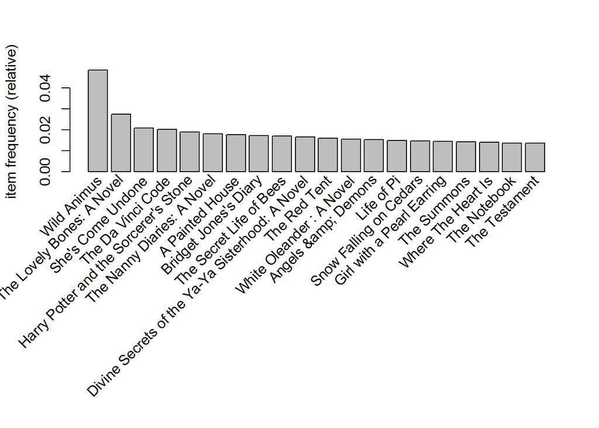

```r
itemFrequencyPlot(bookbasket_use, topN = 20)
```

We can now see the 20 most popular books in the graph agove. We should use these books in our display cases, but remove any books in a series and the book Wild Animus per the store owners request.

# Find any frequent patterns in the data using the apriori model

```r
bookrules <- apriori(bookbasket_use)
```

```
## Apriori
##
## Parameter specification:
##  confidence minval smax arem  aval originalSupport maxtime support minlen
##         0.8    0.1    1 none FALSE            TRUE       5     0.1      1
##  maxlen target   ext
##      10  rules FALSE
##
## Algorithmic control:
##  filter tree heap memopt load sort verbose
##     0.1 TRUE TRUE  FALSE TRUE    2    TRUE
##
## Absolute minimum support count: 4082
##
## set item appearances ...[0 item(s)] done [0.00s].
## set transactions ...[216031 item(s), 40822 transaction(s)] done [1.31s].
## sorting and recoding items ... [0 item(s)] done [0.06s].
## creating transaction tree ... done [0.00s].
## checking subsets of size 1 done [0.00s].
## writing ... [0 rule(s)] done [0.00s].
## creating S4 object  ... done [0.07s].
```

# Try decreasing support and increasing minlen. Also, we want to look for connections with the popular books found above that are not in a series or Wild Animus

```r
bookrules <- apriori(bookbasket_use, parameter = list(support = 0.001, confidence = 0.5, minlen = 2)
                   , appearance = list(lhs = c("The Lovely Bones: A Novel"
                                             , "She's Come Undone"
                                             , "The Nanny Diaries: A Novel"
                                             , "A Painted House"
                                             , "Bridget Jones's Diary"
                                             , "The Secret Life of Bees"
                                             , "Divine Secrets of the Ya-Ya Sisterhood: A Novel"
                                             , "The Red Tent"
                                             , "White Oleander : A Novel"
                                             , "Life of Pi"
                                             , "Snow Falling on Cedars"
                                             , "Girl with a Pearl Earring"
                                             , "Where The Heart Is"
                                             , "The Notebook"), default = "rhs"))
```

```
## Apriori
##
## Parameter specification:
##  confidence minval smax arem  aval originalSupport maxtime support minlen
##         0.5    0.1    1 none FALSE            TRUE       5   0.001      2
##  maxlen target   ext
##      10  rules FALSE
##
## Algorithmic control:
##  filter tree heap memopt load sort verbose
##     0.1 TRUE TRUE  FALSE TRUE    2    TRUE
##
## Absolute minimum support count: 40
##
## set item appearances ...[14 item(s)] done [0.00s].
## set transactions ...[216031 item(s), 40822 transaction(s)] done [1.12s].
## sorting and recoding items ... [3172 item(s)] done [0.09s].
## creating transaction tree ... done [0.04s].
## checking subsets of size 1 2 3 4 done [0.14s].
## writing ... [10 rule(s)] done [0.00s].
## creating S4 object  ... done [0.05s].
```

# View rules

```r
summary(bookrules)
```

```
## set of 10 rules
##
## rule length distribution (lhs + rhs):sizes
## 3 4
## 8 2
##
##    Min. 1st Qu.  Median    Mean 3rd Qu.    Max.
##     3.0     3.0     3.0     3.2     3.0     4.0
##
## summary of quality measures:
##     support           confidence          lift
##  Min.   :0.001029   Min.   :0.5048   Min.   :10.40
##  1st Qu.:0.001090   1st Qu.:0.5081   1st Qu.:10.87
##  Median :0.001176   Median :0.5205   Median :27.09
##  Mean   :0.001186   Mean   :0.5219   Mean   :29.38
##  3rd Qu.:0.001292   3rd Qu.:0.5242   3rd Qu.:47.10
##  Max.   :0.001347   Max.   :0.5600   Max.   :54.98
##
## mining info:
##            data ntransactions support confidence
##  bookbasket_use         40822   0.001        0.5
```

There are many rules with 3-items. This could hint that the store owner should group books by threes.

# Sort by lift and confidence, then write out to a csv file in order to view better

```r
bookrules_sorted <-sort(bookrules, by = c("lift", "confidence"))
write(bookrules_sorted, file = "C:/Users/SK030875/Desktop/MBA/BUS6301/Week4/data/bookrules10.csv",
      sep = ",", quote = TRUE, row.names = FALSE)
```

# View for markdown file

```r
inspect(bookrules_sorted)
```

```
##      lhs                                                  rhs                              support confidence     lift
## [1]  {The Red Tent,
##       Where The Heart Is}                              => {While I Was Gone}           0.001200333  0.5157895 54.97535
## [2]  {The Notebook,
##       White Oleander : A Novel}                        => {Message in a Bottle}        0.001347313  0.5188679 48.46963
## [3]  {Divine Secrets of the Ya-Ya Sisterhood: A Novel,
##       Life of Pi}                                      => {Good in Bed}                0.001151340  0.5222222 47.47919
## [4]  {A Painted House,
##       Life of Pi}                                      => {Good in Bed}                0.001126843  0.5054945 45.95834
## [5]  {Snow Falling on Cedars,
##       Where The Heart Is}                              => {The Pilot's Wife : A Novel} 0.001322816  0.5242718 42.63312
## [6]  {She's Come Undone,
##       The Lovely Bones: A Novel,
##       The Secret Life of Bees}                         => {Wild Animus}                0.001028857  0.5600000 11.53979
## [7]  {She's Come Undone,
##       The Lovely Bones: A Novel,
##       The Nanny Diaries: A Novel}                      => {Wild Animus}                0.001028857  0.5384615 11.09595
## [8]  {A Painted House,
##       The Red Tent}                                    => {Wild Animus}                0.001077850  0.5238095 10.79402
## [9]  {Snow Falling on Cedars,
##       Where The Heart Is}                              => {Wild Animus}                0.001273823  0.5048544 10.40341
## [10] {A Painted House,
##       Snow Falling on Cedars}                          => {Wild Animus}                0.001298320  0.5047619 10.40151
```

# Recommendations:

1. Display “The Red Tent”, “Where The Heart Is”, and “While I Was Gone” together. This combination of books contains 2 of the most popular books and also contains a book that is already on Oprah’s book club list (“While I Was Gone”). Additionally, this rule has the highest lift from the data set, with customers being 55 times more likely to buy the books in combination than alone. The combination of these 3 books should encourage book club members to purchase all 3 together when seeing them in the display, which would increase the sales of all 3 books.
2. Another solid combination is “The Notebook”, “White Oleander : A Novel”, and “Message in a Bottle”. These books are 48 times more likely to be bought together than alone, and should increase sales for the book owner.
3. The last combination to use is “Snow Falling on Cedars”, “Where The Heart Is”, and “The Pilot’s Wife : A Novel”. Again, this combination has strong lift and confidence.

Note: I did not include combinations with the book “Good in Bed” because of the previous assumption made that these books should be appropriate for book club discussion. After researching this book, I did not feel that it fell into this category.